# Spotreba elektrickej energie

Michaela Marčeková

2023

# Úvod

V tomto projekte sa zaoberáme dátami, ktoré sú dostupné na stránke [1]. Obsahujú hodinovú spotrebu elektrickej energie v megawattoch (*MW*) vo východnej časti USA od regionálnej prenosovej organizácie PJM Interconnection. Z dát vyberáme len tie v rokoch 2003 až 2017, nakoľko ostatné roky (2002, 2018) nemajú kompletné dáta.

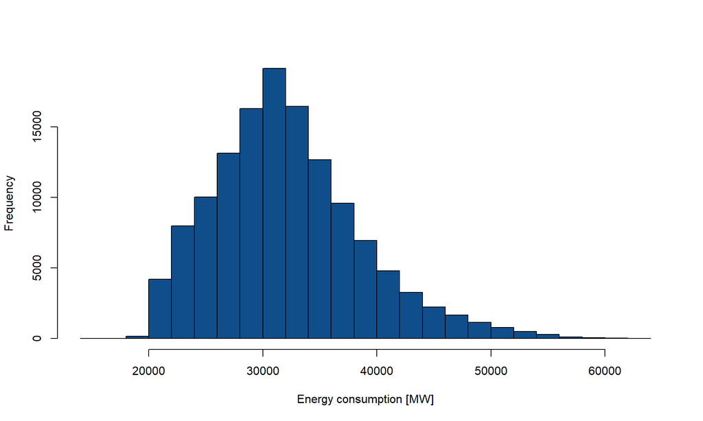

Obrázok 0.1: Histogram hodinovej spotreby energie

```r
df <- read.csv("PJME_hourly.csv")
pom <- strsplit(df$Datetime, " ")
#
pom_date <- sapply(c(1:length(df$Datetime)),
                   \(i){strsplit(pom[[i]][1], "-")})
df$year <- sapply(c(1:length(df$Datetime)),
                   \(i){as.integer(pom_date[[i]][1])})
df$month <- sapply(c(1:length(df$Datetime)),
                   \(i){as.integer(pom_date[[i]][2])})
df$day <- sapply(c(1:length(df$Datetime)),
                   \(i){as.integer(pom_date[[i]][3])})
#
pom_time <- sapply(c(1:length(df$Datetime)),
                   \(i){strsplit(pom[[i]][2], ":")})
df$hour <- sapply(c(1:length(df$Datetime)),
                   \(i){as.integer(pom_time[[i]][1])})
minute <- sapply(c(1:length(df$Datetime)),
                   \(i){as.integer(pom_time[[i]][2])})
second <- sapply(c(1:length(df$Datetime)),
                   \(i){as.integer(pom_time[[i]][3])})
# len cele roky 2003-2017
df <- df[which(!df$year %in% c(2002, 2018)), ]
df$year_month <- paste(as.character(df$year), as.character(df$month))
data <- df$PJME_MW
hist(data, main = "", xlab = "Energy consumption [MW]",
     col = "dodgerblue4")
```

Na histograme vidíme, že rozdelenie hodinovej spotreby energie je zošikmené a v ďalších častiach projektu sa zameriame na modelovanie jeho pravého chvostu.

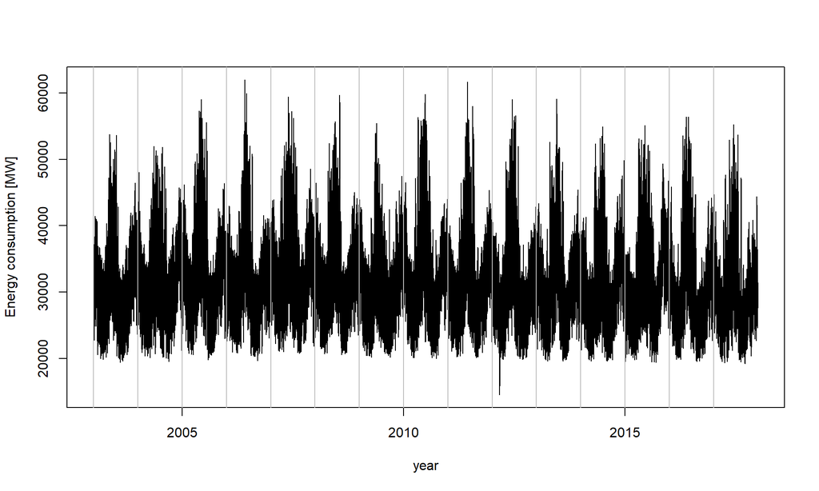

Obrázok 0.2: Hodinová spotreba energie

```r
plot(seq(2003, 2018, length = nrow(df)), data,
     type = "l", xlab = "year", ylab = "Energy consumption [MW]")
for (i in unique(df$year)){
  abline(v = unique(df$year),
         col = "gray")
}
```

Hodinová spotreba energie zjavne tvorí časovú radu, v ktorej sa vyskytuje ročná sezónnosť. Preto sa nejedná o náhodný výber. Metódy, ktoré v tomto projekte používame na modelovanie extrémnych hodnôt, sú formulované pre dáta, ktoré tvoria náhodný výber. V ďalších častiach preto uvidíme, ako sa metódy vysporiadajú s porušeným tohto predpokladu.

Na modelovanie extrémnych hodnôt použijeme metódu blokových maxím a metódu peaks over threshold. Parametre v limitných rozdeleniach odhadujeme dvoma prístupmi – frekventisticky pomocou maximálnej vierohodnosti a bayesovsky pomocou algoritmu Metropolis a aposteriórnej strednej hodnoty.

Cieľom projektu je zodpovedať otázky:

- Aká je pravdepodobnosť, že hodinová spotreba energie presiahne $50\,000\,MW$?
- Aká je pravdepodobnosť, že maximálna hodinová spotreba energie v priebehu jedného mesiaca presiahne $50\,000\,MW$?
- Aká veľká je hodinová spotreba energie, ktorá sa v priemere vyskytuje raz za rok?
- Ako často bude hodinová spotreba energie presahovať $65\,000\,MW$?

# 1 Metóda blokových maxím

Keďže dáta vykazujú ročnú sezónnosť, je vhodné chápať roky ako jednotlivé bloky, z ktorých vyberieme hodnotu maxima. Tým by sme odstránili sezónnosť a mohli by sme predpokladať, že maximá tvoria náhodný výber. To v prípade týchto dát ale nie je možné, keďže pozorujeme dáta iba z 15 rokov, čo by výrazne zhoršilo odhad parametrov *GEV* rozdelenia. Preto ako jednotlivé bloky volíme mesiace, aj keď mesačné maximá netvoria náhodný výber. Dá sa očakávať, že tento prístup nebude viesť k najlepším výsledkom a uvádzame ho len pre porovnanie s POT metódou.

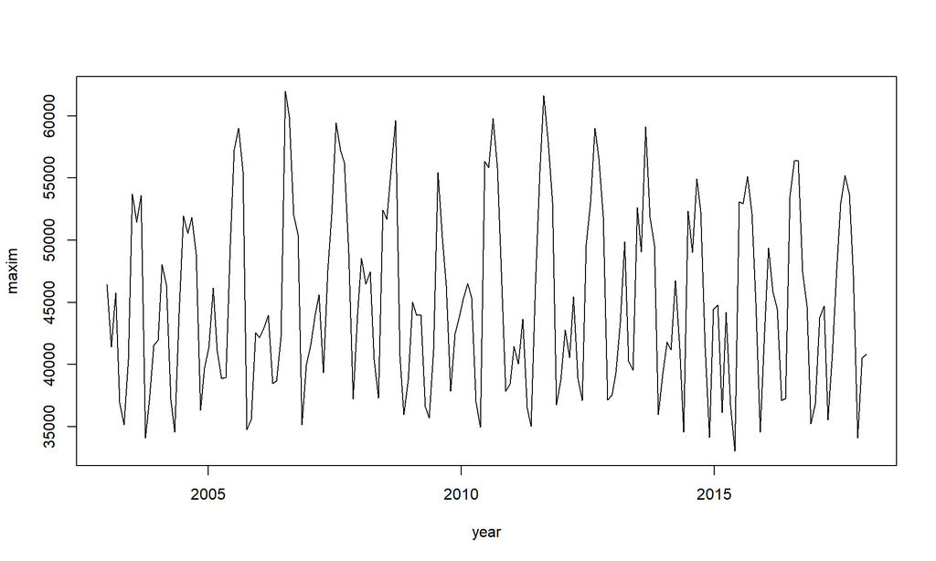

Obrázok 1.1: Mesačné maximá

```r
maxim <- c()
n <- length(unique(df$year_month))
for (i in unique(df$year_month)){
  maxim <- c(maxim, max(data[which(df$year_month == i)]))
}
plot(seq(2003, 2018, length = length(maxim)), maxim,
     type = "l", xlab = "year")
```

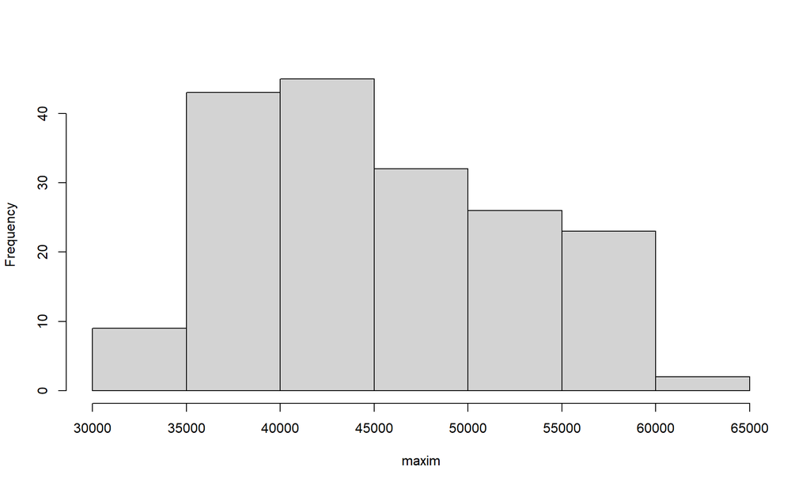

Obrázok 1.2: Histogram mesačných maxím

```r
hist(maxim, main = "")
```

## 1.1 Frekventistický prístup

Parametre *GEV* rozdelenia odhadujeme pomocou metódy maximálnej vierohodnosti implementovanej v balíčku `evd`.

```r
pom <- fgev(maxim)
mu <- pom$estimate[1]
sigma <- pom$estimate[2]
gamma <- pom$estimate[3]
df_est <- data.frame(
  method = "GEV(freq)",
  mu = mu,
  sigma = sigma,
  gamma = gamma
)
row.names(df_est) <- ""
knitr::kable(df_est, "html") %>%
  kable_styling(position = "center")
```

|  | method | mu | sigma | gamma |
| --- | --- | --- | --- | --- |
|  | GEV(freq) | 41885.57 | 5812.082 | -0.0555078 |

## 1.2 Bayesovský prístup

Parametre *GEV* rozdelenia odhadujeme ešte aj pomocou bayesovského prístupu. Inširovali sme sa pri tom stránkou [2] a článkom [3]. Predpokladáme, že parametre $\mu$, $\sigma$ a $\gamma$ sú apriórne nezávislé, a preto môžeme ich apriórne rozdelenie formulovať pomocou ich marginálnych rozdelení. Narozdiel od vyššie spomenutej literatúry, apriórne rozdelenie volíme ako čiastočne informatívne, a to

$$\mu \sim N(\hat\mu_{MLE}, 1000)\quad\sigma \sim N(\hat\sigma_{MLE}, 1000)\quad\gamma \sim N(\hat\gamma_{MLE}, 1000).$$

V spomínanej literatúre používali ako apriórne rozdelenia tiež normálne s veľkým rozptylom, ale stredná hodnota bola pre všetky parametre rovná nule. Naša voľba apriórneho rozdelenia využíva frekventistické odhady z predchádzajúcej časti. Tento prístup nie je neobvyklý, práve naopak – apriórne rozdelenia sa často formulujú pomocou frekventistických odhadov na zlepšenie bayesovského odhadu. Veľký rozptyl apriórnych rozdelení zabezpečuje, že aposteriórne rozdelenie sa viac prispôsobí samotným dátam než našej voľbe apriórneho rozdelenia.

Analytický tvar aposteriórneho rozdelenia parametrov $(\mu, \sigma, \gamma)'$ nie je známy, a preto ho popisujeme pomocou simulácie vzorky parametrov z tohto rozdelenia. Na získanie vzorky používame algoritmus Metropolis s 3-rozmerným normálnym navrhujúcim rozdelením s nulovými kovarianciami a rozptylmi $(200, 200, 1)$. Ako počiatočnú hodnotu parametrov volíme vektor $(\hat\mu_{MLE}, \hat\sigma_{MLE}, \hat\gamma_{MLE})'$. Dostávame vzorku $10^5$ realizácií parametrov $(\mu, \sigma, \gamma)'$.

```r
M3 <- function(N = 1e3, sigma = c(1, 2, 2), x0 = c(0, 1, 0)) {
  X <- matrix(rep(0, 3*N), nrow =  3)
  X[, 1] <- x <- x0
  set.seed(42)
  for (i in 2:N) {
    candidates <- x +
      rmvnorm(1,  mean = rep(0, times = 3), sigma = diag(sigma))
    if (candidates[2] <= 0){
      candidates[2] <- 0.1
    }
    r <- sum(evd::dgev(maxim, loc = candidates[1], scale = candidates[2],
                  shape = candidates[3], log = TRUE)) +
      dmvnorm(candidates, mean = x0, sigma = 1000*diag(3),
              log = TRUE) -
      sum(evd::dgev(maxim, loc = x[1], scale = x[2], shape = x[3],
               log = TRUE)) -
      dmvnorm(x, mean = x0, sigma = 1000*diag(3),
              log = TRUE)
    if ((r >= log(1)) || (log(runif(1)) <= r)){
      X[, i] <- x <- candidates
    }else{
      X[, i] <- x
    }
  }
  return(X)
}
N <- 1e5
sigma <- c(200, 200, 1)
x0 <- c(df_est$mu[1], df_est$sigma[1], df_est$gamma[1])
set.seed(42)
samples <- M3(N = N, sigma = sigma, x0 = x0)
df_samples <- data.frame(
  k = seq(1, N),
  mu = samples[1, ],
  sigma = samples[2, ],
  gamma = samples[3, ])
df_samples_gg <- data.frame(
  k = rep(seq(1, N), times = 3),
  sample = c(samples[1, ], samples[2, ], samples[3, ]),
  params = c(rep('mu', times = N),
             rep('sigma', times = N),
             rep('gamma', times = N)))
save(df_samples, file = "df_samples1.Rdata")
save(df_samples_gg, file = "df_samples_gg1.Rdata")
```

```r
N <- 1e5
load("df_samples1.Rdata")
load("df_samples_gg1.Rdata")
```

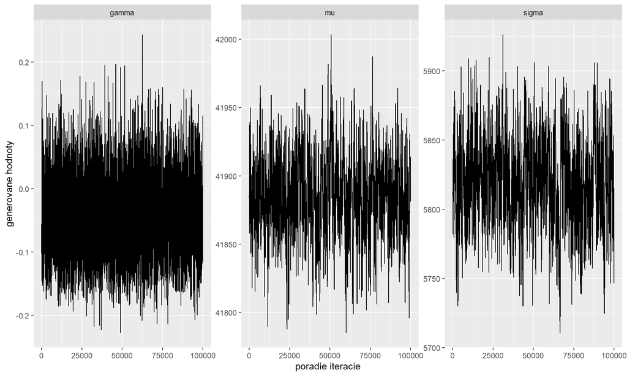

Obrázok 1.3: Stopový graf vzorky parametrov

```r
# Trace plot
df_samples_gg |> ggplot(aes(x = k, y = sample, group = params)) +
  geom_line() + xlab("poradie iteracie") + ylab("generovane hodnoty") +
  facet_wrap(~params, scales = "free")
```

Na stopovom grafe vzorky parametrov vidíme, že algoritmus Metropolis úspešne prehľadal obor hodnôt parametrov.

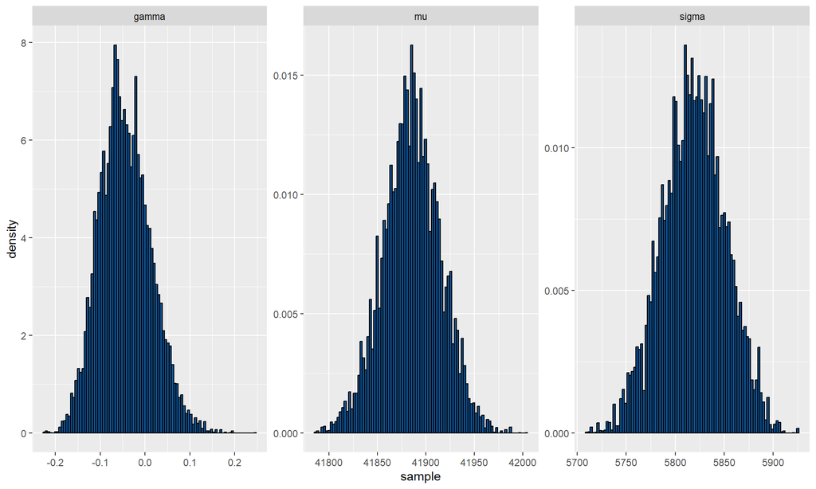

Obrázok 1.4: Histogram vzorky parametrov z aposteriórneho rozdelenia

```r
# Histogram
df_samples_gg |> ggplot(aes(x = sample, y = after_stat(density))) +
  geom_histogram(colour = "black", fill = "dodgerblue4",
                 bins = ceiling(2*N^(1/3))) +
  facet_wrap(~params, scales = "free")
```

Na histogramoch vidíme odhad aposteriórneho rozdelenia parametrov. Odhady parametrov počítame pomocou odhadu aposteriórnej strednej hodnoty a uvádzame ich v nasledujúcej tabuľke. Vidíme, že sa nelíšia výrazne od frekventistických odhadov.

```r
# Odhady parametrov pomocou aposteriornej strednej hodnoty
mu <- mean(df_samples$mu)
sigma <- mean(df_samples$sigma)
gamma <- mean(df_samples$gamma)
df_est <- rbind(df_est,
  data.frame(
  method = "GEV(bayes)",
  mu = mu,
  sigma = sigma,
  gamma = gamma
))
row.names(df_est) <- c(1:nrow(df_est))
knitr::kable(df_est, "html", row.names = FALSE) %>%
  kable_styling(position = "center")
```

| method | mu | sigma | gamma |
| --- | --- | --- | --- |
| GEV(freq) | 41885.57 | 5812.082 | -0.0555078 |
| GEV(bayes) | 41885.29 | 5818.857 | -0.0438254 |

# 2 Metóda peaks over threshold

V metóde peaks over threshold (*POT*) volíme hranicu $u$ ako empirický $0.96$-kvantil hodinovej spotreby energie. Na residual life plote sme vyznačili túto hranicu červenou zvislou čiarou. Vidíme, že približne od tejto hodnoty je mean residual life lineárny.

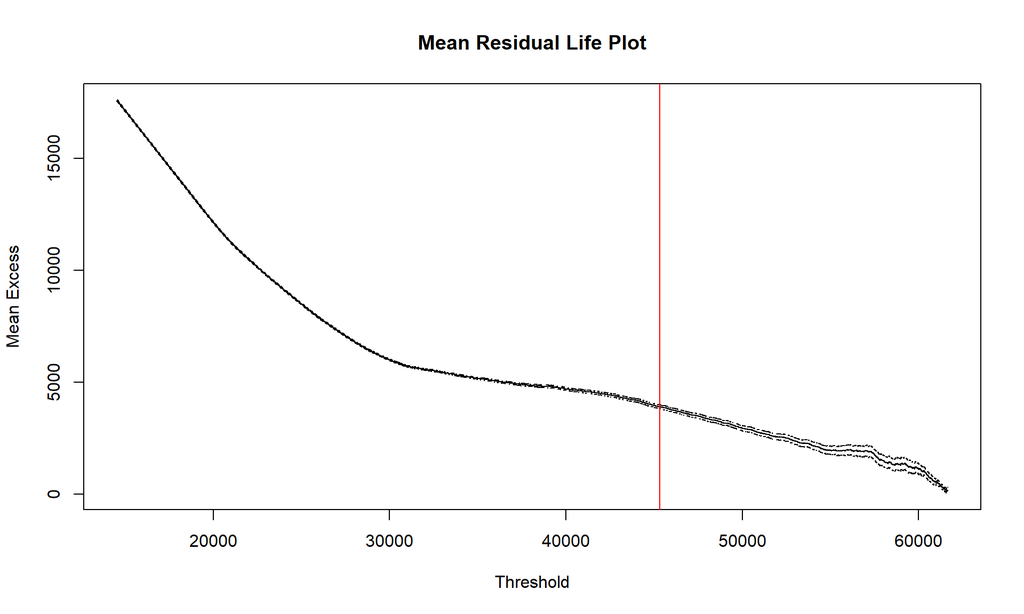

Obrázok 2.1: Mean residual life plot s vyznačenou hranicou

```r
u <- quantile(data, 0.96)
mrlplot(data)
abline(v = u, col = "red")
```

V nasledujúcej tabuľke je uvedená hodnota hranice $u$, počet excesov a ich základné charakteristiky.

```r
peaks <- data[which(data > u)] - u
df_peaks <- data.frame(
  u = u,
  num = length(peaks),
  min = min(peaks),
  max = max(peaks),
  mean = mean(peaks),
  sd = sqrt(var(peaks))
)
knitr::kable(df_peaks, "html", row.names = FALSE) %>%
  kable_styling(position = "center")
```

| u | num | min | max | mean | sd |
| --- | --- | --- | --- | --- | --- |
| 45313.12 | 5259 | 0.88 | 16695.88 | 3913.78 | 3197.234 |

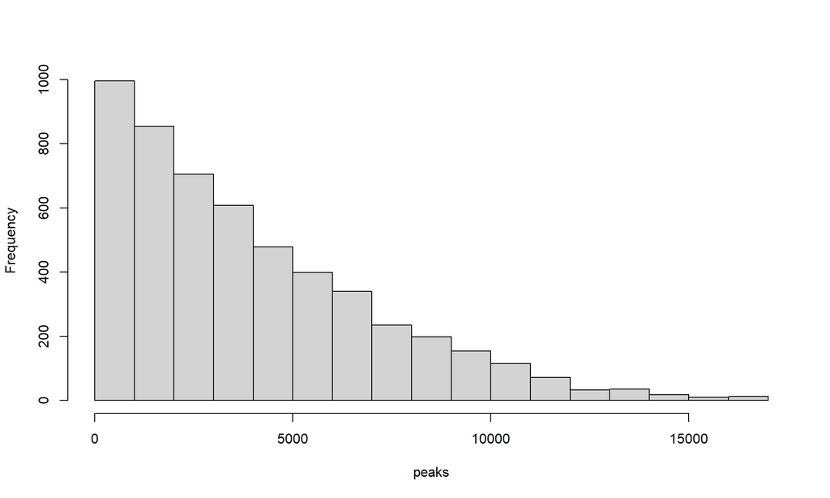

Obrázok 2.2: Histogram excesov

```r
hist(peaks, main = "")
```

## 2.1 Frekventistický prístup

Parametre *GPD* rozdelenia odhadujeme pomocou metódy maximálnej vierohodnosti implementovanej v balíčku `evd`.

```r
pom <- fpot(data, threshold = u)
mu <- 0
sigma <- pom$estimate[1]
gamma <- pom$estimate[2]
df_est <- rbind(df_est,
  data.frame(
  method = "GPD(freq)",
  mu = mu,
  sigma = sigma,
  gamma = gamma
))
knitr::kable(df_est[3, c(1, 3, 4)], "html", row.names = FALSE) %>%
  kable_styling(position = "center")
```

| method | sigma | gamma |
| --- | --- | --- |
| GPD(freq) | 4466.777 | -0.1982393 |

Parameter polohy $\mu$ je pevne zvolený ako nula, keďže excesy nadobúdajú nezáporné hodnoty. Odhad parametru tvaru $\gamma$ vyšiel záporný, ale nie menší ako $-0.5$. Ak je aj skutočná hodnota parametru $\gamma$ väčšia ako $-0.5$, tento odhad je konzistentný.

## 2.2 Bayesovský prístup

Parametre *GPD* rozdelenia odhadujeme aj pomocou bayesovského prístupu. Opäť predpokladáme, že parametre $\sigma$ a $\gamma$ sú apriórne nezávislé, a ich apriórne rozdelenie volíme ako

$$\sigma \sim N(\hat\sigma_{MLE}, 1000)\quad\gamma \sim N(\hat\gamma_{MLE}, 1000).$$

Aposteriórne rozdelenie $(\sigma, \gamma)'$ popisujeme pomocou simulácie vzorky parametrov z tohto rozdelenia. Opäť používame algoritmus Metropolis. Navrhujúce rozdelenie je 2-rozmerné normálne s nulovou kovarianciou a rozptylmi $(350, 0.3)$. Ako počiatočnú hodnotu parametrov volíme vektor $(\hat\sigma_{MLE}, \hat\gamma_{MLE})'$. Dostávame vzorku $10^5$ realizácií parametrov $(\sigma, \gamma)'$.

```r
M2 <- function(N = 1e3, sigma = c(1, 1), x0 = c(1, 0)) {
  X <- matrix(rep(0, 2*N), nrow =  2)
  X[, 1] <- x <- x0
  set.seed(42)
  for (i in 2:N) {
    candidates <- x +
      rmvnorm(1,  mean = rep(0, times = 2), sigma = diag(sigma))
    if (candidates[1] <= 0){
      candidates[1] <- 0.1
    }
    r <- sum(evd::dgpd(peaks, loc = 0, scale = candidates[1],
                  shape = candidates[2], log = TRUE)) +
      dmvnorm(candidates, mean = x0, sigma = 1000*diag(2),
              log = TRUE) -
      sum(evd::dgpd(peaks, loc = 0, scale = x[1], shape = x[2],
               log = TRUE)) -
      dmvnorm(x, mean = x0, sigma = 1000*diag(2),
              log = TRUE)
    if ((r >= log(1)) || (log(runif(1)) <= r)){
      X[, i] <- x <- candidates
    }else{
      X[, i] <- x
    }
  }
  return(X)
}
N <- 1e5
sigma <- c(350, 0.3)
x0 <- c(df_est$sigma[3], df_est$gamma[3])
set.seed(42)
samples <- M2(N = N, sigma = sigma, x0 = x0)
df_samples <- data.frame(
  k = seq(1, N),
  sigma = samples[1, ],
  gamma = samples[2, ])
df_samples_gg <- data.frame(
  k = rep(seq(1, N), times = 2),
  sample = c(samples[1, ], samples[2, ]),
  params = c(rep('sigma', times = N),
             rep('gamma', times = N)))
save(df_samples, file = "df_samples2.Rdata")
save(df_samples_gg, file = "df_samples_gg2.Rdata")
```

```r
load("df_samples2.Rdata")
load("df_samples_gg2.Rdata")
```

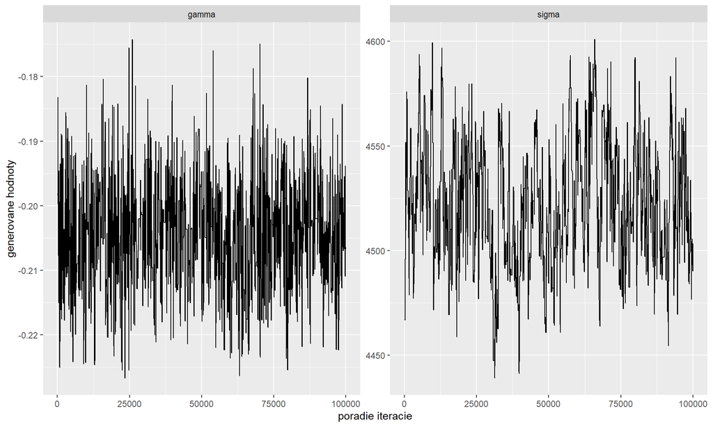

Obrázok 2.3: Stopový graf vzorky parametrov

```r
# Trace plot
df_samples_gg |> ggplot(aes(x = k, y = sample, group = params)) +
  geom_line() + xlab("poradie iteracie") + ylab("generovane hodnoty") +
  facet_wrap(~params, scales = "free")
```

Na stopovom grafe vzorky parametrov vidíme, že algoritmus Metropolis úspešne prehľadal obor hodnôt parametru $\gamma$ a o niečo menej úspešne obor hodnôt parametru $\sigma$. Skúšali sme viaceré spustenia algoritmu Metropolis s rôznymi ladiacimi parametrami (rozptylmi v navrhujúcom rozdelení), ale nepodarilo sa nám nájsť optimálny, pre ktorý by stopový graf parametru $\sigma$ vyzeral lepšie. Tieto nedostatky by sa ale nemali výrazne prejaviť na odhade aposteriórneho rozdelenia, nakoľko sme ich nahradili veľkým počtom iterácií.

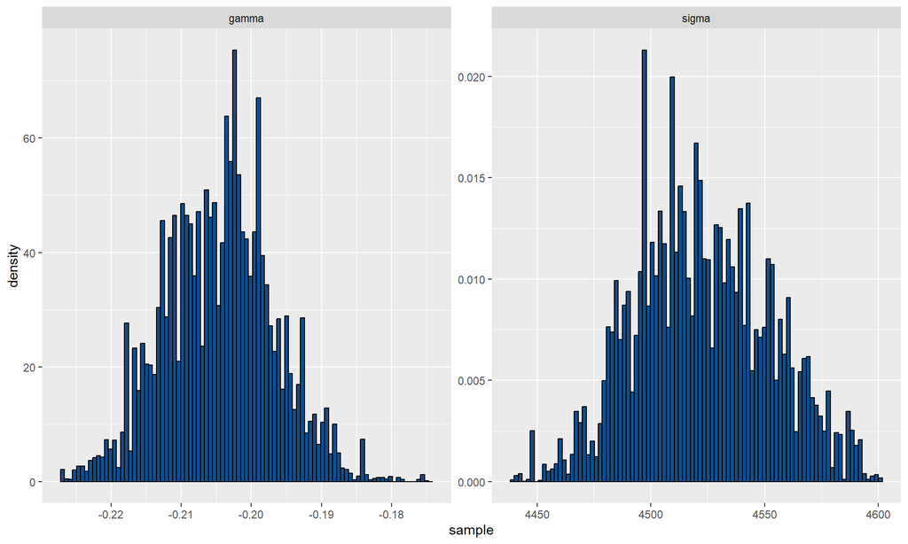

Obrázok 2.4: Histogram vzorky parametrov z aposteriórneho rozdelenia

```r
# Histogram
df_samples_gg |> ggplot(aes(x = sample, y = after_stat(density))) +
  geom_histogram(colour = "black", fill = "dodgerblue4",
                 bins = ceiling(2*N^(1/3))) +
  facet_wrap(~params, scales = "free")
```

Na histogramoch vidíme odhad aposteriórneho rozdelenia parametrov. Odhady parametrov počítame pomocou odhadu aposteriórnej strednej hodnoty a uvádzame ich v nasledujúcej tabuľke. Tak, ako v prípade *GEV* rozdelenia, aj pre *GPD* rozdelenie sa nelíšia výrazne od frekventistických odhadov.

```r
# Odhady parametrov pomocou aposteriornej strednej hodnoty
mu <- 0
sigma <- mean(df_samples$sigma)
gamma <- mean(df_samples$gamma)
df_est <- rbind(df_est,
  data.frame(
  method = "GPD(bayes)",
  mu = mu,
  sigma = sigma,
  gamma = gamma
))
row.names(df_est) <- c(1:nrow(df_est))
knitr::kable(df_est[c(3:4), c(1, 3, 4)], "html", row.names = FALSE) %>%
  kable_styling(position = "center")
```

| method | sigma | gamma |
| --- | --- | --- |
| GPD(freq) | 4466.777 | -0.1982393 |
| GPD(bayes) | 4522.610 | -0.2045198 |

# 3 Výber modelu

Rozdelenie extrémnych hodnôt hodinovej spotreby energie sme popísali pomocou štyroch rozdelení, a to *GEV* a *GPD*, každé s parametrami odhadnutými pomocou frekventistického a bayesovského prístupu. V tejto časti vykreslíme odhadnuté rozdelenia a porovnáme ich.

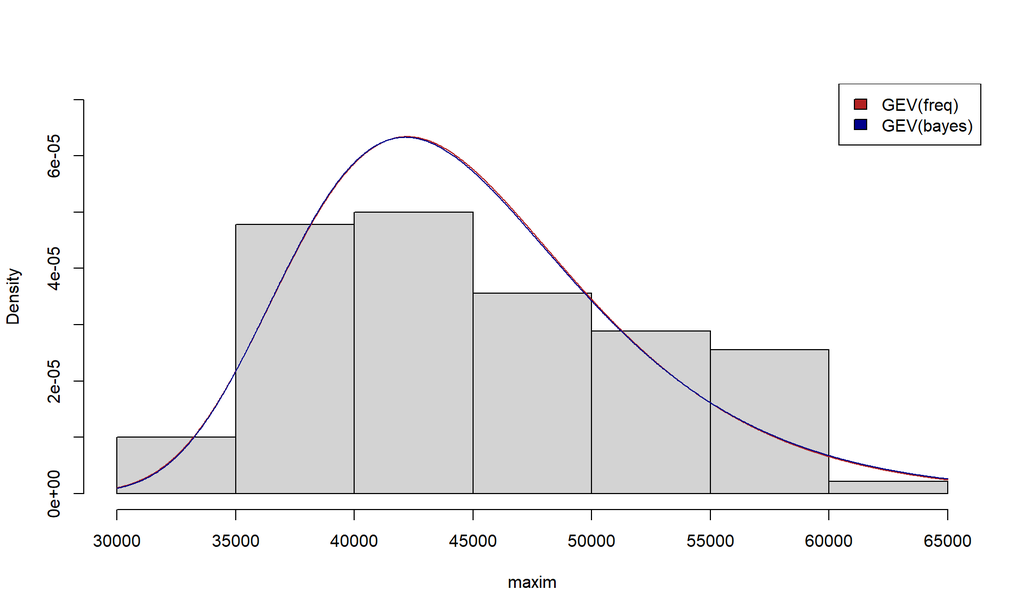

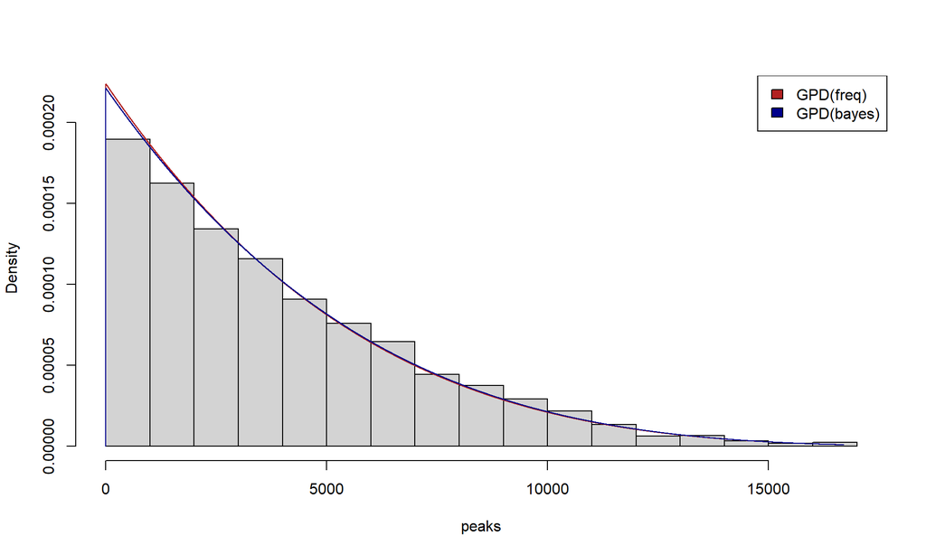

Obrázok 3.1: Histogramy mesačných maxím a excesov

```r
hist(maxim, freq = FALSE, ylim = c(0, 7*10^(-5)), main = "")
dgev_est1 <- function(x){
  evd::dgev(x, df_est$mu[1], df_est$sigma[1], df_est$gamma[1])
}
curve(dgev_est1, from = 30000, to = 65000, n = 1001,
      col = "firebrick", add = TRUE)
dgev_est2 <- function(x){
  evd::dgev(x, df_est$mu[2], df_est$sigma[2], df_est$gamma[2])
}
curve(dgev_est2, from = 30000, to = 65000, n = 1001,
      col = "darkblue", add = TRUE)
legend("topright", legend = c(df_est$method[1], df_est$method[2]),
       fill = c("firebrick", "darkblue"))

hist(peaks, freq = FALSE, main = "", ylim = c(0, 0.00022),
     breaks = 1/2*ceiling(2*length(peaks)^(1/3)))
dgpd_est1 <- function(x){
  evd::dgpd(x, df_est$mu[3], df_est$sigma[3], df_est$gamma[3])
}
curve(dgpd_est1, from = 0, to = max(peaks), n = 10001,
      col = "firebrick", add = TRUE)
dgpd_est2 <- function(x){
  evd::dgpd(x, df_est$mu[4], df_est$sigma[4], df_est$gamma[4])
}
curve(dgpd_est2, from = 0, to = max(peaks), n = 10001,
      col = "darkblue", add = TRUE)
legend("topright", legend = c(df_est$method[3], df_est$method[4]),
       fill = c("firebrick", "darkblue"))
```

Na oboch histogramoch sa hustoty *GEV* a *GPD* rozdelenia takmer prekrývajú, a teda ani jeden z prístupov (frekventistický či bayesovský) sa nejaví výrazne lepší. Hustoty *GEV* a *GPD* rozdelení tvarom približne pripomínajú histogram maxím, respektíve excesov. Lepší výsledok dostávame pre *GPD* rozdelenie, aj keď je náročné to porovnať s *GEV* rozdelením, keďže sa jedná o rozdelenia na iných dátach (a iných histogramoch).

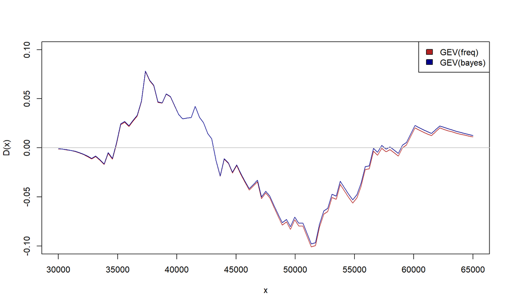

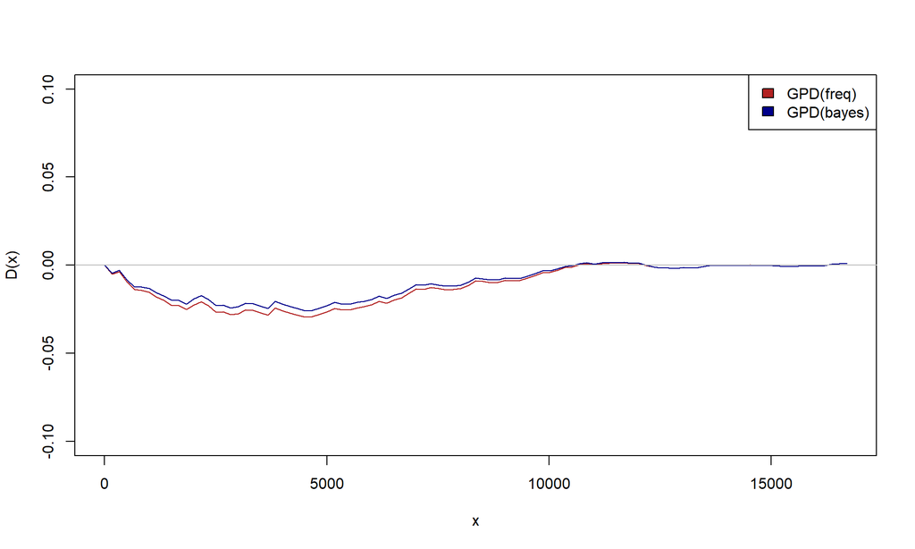

Obrázok 3.2: Odchýlky teoretickej distribučnej funkcie od empirickej pre mesačné maximá (GEV rozdelenie) a excesy (GPD rozdelenie)

```r
# Odchylka distribucnej funkcie
D1_freq <- function(x){
  D1 <- ecdf(maxim)(x) - evd::pgev(x, df_est$mu[1], df_est$sigma[1],
                                   df_est$gamma[1])
}

D1_bayes <- function(x){
  D1 <- ecdf(maxim)(x) - evd::pgev(x, df_est$mu[2], df_est$sigma[2],
                                   df_est$gamma[2])
}

D2_freq <- function(x){
  D2 <- ecdf(peaks)(x) - evd::pgpd(x, df_est$mu[3], df_est$sigma[3],
                                  df_est$gamma[3])
}

D2_bayes <- function(x){
  D2 <- ecdf(peaks)(x) - evd::pgpd(x, df_est$mu[4], df_est$sigma[4],
                                  df_est$gamma[4])
}

curve(D1_freq, 30000, 65000, ylim = c(-0.1, 0.1), ylab = "D(x)",
      col = "firebrick")
curve(D1_bayes, add = TRUE, col = "darkblue")
abline(h = 0, col = "gray")
legend("topright", legend = c(df_est$method[1], df_est$method[2]),
       fill = c("firebrick", "darkblue"))

curve(D2_freq, 0, 16700, ylim = c(-0.1, 0.1), ylab = "D(x)",
      col = "firebrick")
curve(D2_bayes, add = TRUE, col = "darkblue")
abline(h = 0, col = "gray")
legend("topright", legend = c(df_est$method[3], df_est$method[4]),
       fill = c("firebrick", "darkblue"))
```

Na predchádzajúcich obrázkoch sú uvedené odchýlky empirických distribučných funkcií (maxím, excesov) od teoretických (*GEV*, *GPD*) s odhadnutými parametrami. Menšie odchýlky pozorujeme na grafe *GPD* rozdelenia. Na ňom sa ako o trochu lepší model javí bayesovský.

```r
# Testova statistika
df_D <- data.frame(
  GEV_freq = max(abs(D1_freq(maxim))),
  GEV_bayes = max(abs(D1_bayes(maxim))),
  GPD_freq = max(abs(D2_freq(peaks))),
  GPD_bayes = max(abs(D2_bayes(peaks)))
)

# Bootstrap
D_gev <- function(x, mu, sigma, gamma){
  D1 <- ecdf(maxim)(x) - evd::pgev(x, mu, sigma, gamma)
}

D_gpd <- function(x, mu, sigma, gamma){
  D2 <- ecdf(peaks)(x) - evd::pgpd(x, mu, sigma, gamma)
}

df_p_val <- data.frame(
  GEV_freq = 0,
  GEV_bayes = 0,
  GPD_freq = 0,
  GPD_bayes = 0
)

n_iter <- 1000
for (i in c(1:n_iter)){
  # GEV freq
  sample <- evd::rgev(length(maxim), df_est$mu[1], df_est$sigma[1],
                      df_est$gamma[1])

  pom <- fgev(sample, std.err = FALSE)
  mu <- pom$estimate[1]
  sigma <- pom$estimate[2]
  gamma <- pom$estimate[3]
  df_p_val$GEV_freq <- df_p_val$GEV_freq +
    ifelse(max(abs(D_gev(sample, mu, sigma, gamma))) >=
             df_D$GEV_freq, 1, 0)
  # GEV bayes
  sample <- evd::rgev(length(maxim), df_est$mu[2], df_est$sigma[2],
                      df_est$gamma[2])

  pom <- fgev(sample, std.err = FALSE)
  mu <- pom$estimate[1]
  sigma <- pom$estimate[2]
  gamma <- pom$estimate[3]
  df_p_val$GEV_bayes <- df_p_val$GEV_bayes +
    ifelse(max(abs(D_gev(sample, mu, sigma, gamma))) >=
             df_D$GEV_bayes, 1, 0)
  # GPD freq
  sample <- evd::rgpd(length(peaks), df_est$mu[3], df_est$sigma[3],
                      df_est$gamma[3])

  pom <- fpot(sample, threshold = 0, std.err = FALSE)
  mu <- 0
  sigma <- pom$estimate[1]
  gamma <- pom$estimate[2]
  df_p_val$GPD_freq <- df_p_val$GPD_freq +
    ifelse(max(abs(D_gpd(sample, mu, sigma, gamma))) >=
             df_D$GPD_freq, 1, 0)
  # GPD bayes
  sample <- evd::rgpd(length(peaks), df_est$mu[4], df_est$sigma[4],
                      df_est$gamma[4])

  pom <- fpot(sample, threshold = 0, std.err = FALSE)
  mu <- 0
  sigma <- pom$estimate[1]
  gamma <- pom$estimate[2]
  df_p_val$GPD_bayes <- df_p_val$GPD_bayes +
    ifelse(max(abs(D_gpd(sample, mu, sigma, gamma))) >=
             df_D$GPD_bayes, 1, 0)
}
df_p_val <- df_p_val/n_iter
row.names(df_p_val) <- "p_val"
knitr::kable(df_p_val, "html") %>%
  kable_styling(position = "center")
```

|  | GEV_freq | GEV_bayes | GPD_freq | GPD_bayes |
| --- | --- | --- | --- | --- |
| p_val | 0.858 | 0.818 | 0.985 | 0.986 |

Vyššie uvedené p-hodnoty sú z Kolmogorovho-Smirnovho testu na posúdenie, či dáta (maximá, excesy) pochádzajú z daného rozdelenia (*GEV*, *GPD*). Nakoľko sme parametre v rozdeleniach odhadovali, test implementujeme pomocou parametrického bootstrapu. Aj pre frekventistické, aj bayesovské odhady používame v každej iterácii na odhady parametrov zo vzoriek frekventistický prístup, nakoľko bayesovský by dramaticky zvýšil časovú náročnosť. Na základe tohto testu nezamietame žiaden z modelov, a teda všetky štyri sú vhodné na modelovanie extrémov.

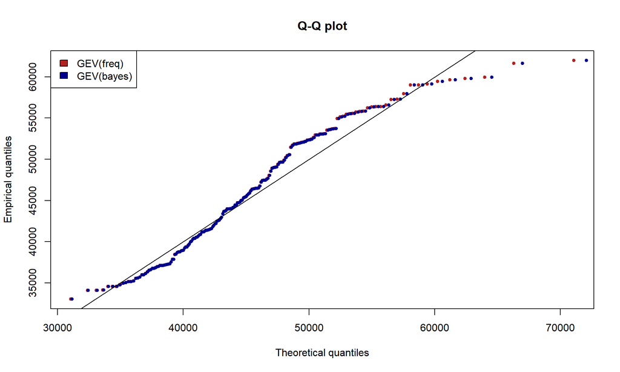

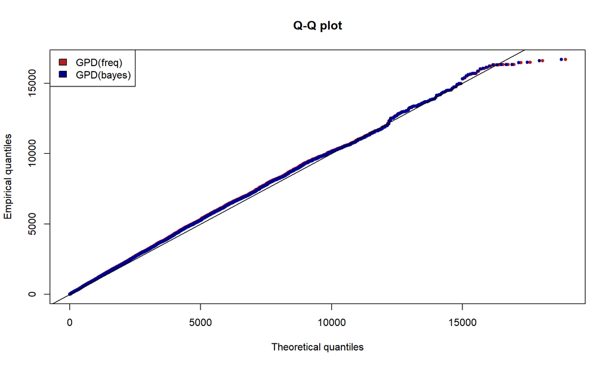

Obrázok 3.3: Q-Q plot: mesačné maximá proti kvantilom GEV rozdelenia a excesy proti kvantilom GPD rozdelenia

```r
# Q-Q plot
N <- length(maxim)
i <- 1:N
q1 <- evd::qgev((i-0.5)/N, df_est$mu[1], df_est$sigma[1],
             df_est$gamma[1])
q2 <- evd::qgev((i-0.5)/N, df_est$mu[2], df_est$sigma[2],
             df_est$gamma[2])
plot(sort(maxim) ~ q1, xlab='Theoretical quantiles',
     ylab='Empirical quantiles', main='Q-Q plot',
     pch = 20, col = "firebrick")
points(sort(maxim) ~ q2, pch = 20, col = "darkblue")
abline(0,1)
legend("topleft", legend = c(df_est$method[1], df_est$method[2]),
       fill = c("firebrick", "darkblue"))

N <- length(peaks)
i <- 1:N
q1 <- evd::qgpd((i-0.5)/N, df_est$mu[3], df_est$sigma[3],
             df_est$gamma[3])
q2 <- evd::qgpd((i-0.5)/N, df_est$mu[4], df_est$sigma[4],
             df_est$gamma[4])
plot(sort(peaks) ~ q1, xlab='Theoretical quantiles',
     ylab='Empirical quantiles', main='Q-Q plot',
     pch = 20, col = "firebrick")
points(sort(peaks) ~ q2, pch = 20, col = "darkblue")
abline(0,1)
legend("topleft", legend = c(df_est$method[3], df_est$method[4]),
       fill = c("firebrick", "darkblue"))
```

Podľa Q-Q plotov odhadnuté *GPD* rozdelenie lepšie zodpovedá excesom než odhadnuté *GEV* rozdelenie mesačným maximám. Vo frekventistickom a bayesovskom prístupe opäť nie je vidieť veľký rozdiel ani pre *GEV*, ani *GPD* rozdelenie.

Celkovo by sme zhodnotili, že *GPD* rozdelenie sa javí ako lepší z modelov na extrémne hodnoty. V bayesovskom a frekventistickom prístupe nie je vidieť veľké rozdiely, a preto je možné použiť ľubovoľný z nich.

# 4 Výsledky

Na záver zodpovieme otázky, ktoré sme stanovili v úvode. Odpovede uvádzame pre všetky štyri metódy a zvýrazňujeme odpovede získané pomocou *POT* metódy, keďže sa nám javila ako vhodnejšia.

```r
# ================================================================
# GEV

# P(X > 50000)
df_answers <- data.frame(
  answer = "answer1",
  GEV_freq = 1 - evd::pgev(50000, df_est$mu[1], df_est$sigma[1],
              df_est$gamma[1])^(1/(30*24)),
  GEV_bayes = 1 - evd::pgev(50000, df_est$mu[2], df_est$sigma[2],
                             df_est$gamma[2])^(1/(30*24))
)

# P(M > 50000)
df_answers <- rbind(df_answers, data.frame(
  answer = "answer2",
  GEV_freq = 1 - evd::pgev(50000, df_est$mu[1], df_est$sigma[1],
                           df_est$gamma[1]),
  GEV_bayes = 1 - evd::pgev(50000, df_est$mu[2], df_est$sigma[2],
                            df_est$gamma[2])
))

# Uroven navratu
# 1 rok = 12 mesiacov
df_answers <- rbind(df_answers, data.frame(
  answer = "answer3a",
  GEV_freq = evd::qgev(1 - 1/12, df_est$mu[1], df_est$sigma[1],
                       df_est$gamma[1]),   # rokov
  GEV_bayes = evd::qgev(1 - 1/12, df_est$mu[2], df_est$sigma[2],
                       df_est$gamma[2])   # rokov
))

df_answers <- rbind(df_answers, data.frame(
  answer = "answer3b",
  GEV_freq = evd::qgev((1 - 1/(12*30*24))^(30*24), df_est$mu[1],
                        df_est$sigma[1], df_est$gamma[1]),   # rokov
  GEV_bayes = evd::qgev((1 - 1/(12*30*24))^(30*24), df_est$mu[2],
                        df_est$sigma[2], df_est$gamma[2])   # rokov
))

# Doba navratu
df_answers <- rbind(df_answers, data.frame(
  answer = "answer4a",
  GEV_freq = 1/( 1 - evd::pgev(65000, df_est$mu[1],
                               df_est$sigma[1],
                               df_est$gamma[1]) )/12,   # rokov
  GEV_bayes = 1/( 1 - evd::pgev(65000, df_est$mu[2],
                                df_est$sigma[2],
                                df_est$gamma[2]) )/12   # rokov
))

df_answers <- rbind(df_answers, data.frame(
  answer = "answer4b",
  GEV_freq = 1/( 1 - evd::pgev(65000, df_est$mu[1],
                               df_est$sigma[1],
                               df_est$gamma[1])^
                   (1/(30*24)))/(12*30*24), #rokov
  GEV_bayes = 1/( 1 - evd::pgev(65000, df_est$mu[2],
                                df_est$sigma[2],
                                df_est$gamma[2])^
                    (1/(30*24)))/(12*30*24) #rokov
))

# ================================================================
# GPD

# P(X > u)
pst <- length(peaks)/length(data)

# P(X > 50000)
df_answers2 <- data.frame(
  answer = "answer1",
  GPD_freq = (1 - evd::pgpd(50000 - u, df_est$mu[3],
                            df_est$sigma[3],
                            df_est$gamma[3]))*pst,
  GPD_bayes = (1 - evd::pgpd(50000 - u, df_est$mu[4],
                             df_est$sigma[4],
                             df_est$gamma[4]))*pst
)

# P(max(X1, ..., X24*30) > 50000)
# 1 - P(max(X1, ..., X24*30) <= 50000)
# 1 - P(X1 <= 50000)*...*(X24*30 <= 50000)
# 1 - prod 1 - P(X_i > 50000)
# 1 - prod 1 - P(Y_i > 50000 - u)
# 1 - (1 - P(X_i > 50000))^24*30
df_answers2 <- rbind(df_answers2, data.frame(
  answer = "answer2",
  GPD_freq = 1 - (1 - df_answers2[1, 2])^(24*30),
  GPD_bayes = 1 - (1 - df_answers2[1, 3])^(24*30)
))

# Uroven navratu
# 1 rok = 12 mesiacov
df_answers2 <- rbind(df_answers2, data.frame(
  answer = "answer3a",
  GPD_freq = u + df_est$sigma[3]/df_est$gamma[3] *
    ( (12*30*24*pst)^df_est$gamma[3] - 1 ),   # rokov
  GPD_bayes = u + df_est$sigma[4]/df_est$gamma[4] *
    ( (12*30*24*pst)^df_est$gamma[4] - 1 )   # rokov
))

df_answers2 <- rbind(df_answers2, data.frame(
  answer = "answer3b",
  GPD_freq = NaN,   # rokov
  GPD_bayes = NaN   # rokov
))

# Doba navratu
df_answers2 <- rbind(df_answers2, data.frame(
  answer = "answer4a",
  GPD_freq = 1/( (1 - evd::pgpd(65000 - u, df_est$mu[3],
                                df_est$sigma[3],
                                df_est$gamma[3]))*pst )/(24*30*12),
  # rokov
  GPD_bayes = 1/( (1 - evd::pgpd(65000 - u, df_est$mu[4],
                                 df_est$sigma[4],
                                 df_est$gamma[4]))*pst )/(24*30*12)
  # rokov
))

df_answers2 <- rbind(df_answers2, data.frame(
  answer = "answer4b",
  GPD_freq = NaN, #rokov
  GPD_bayes = NaN #rokov
))

# ================================================================
# Solution

df_answers <- cbind(df_answers, df_answers2[, c(2:3)])
pom <- format(round(df_answers[c(1:2), c(2:5)], 6), nsmall = 6)
df_answers[c(3:6), c(2:5)] <-
  format(round(df_answers[c(3:6), c(2:5)], 2), nsmall = 2)
df_answers[c(1:2), c(2:5)] <- pom
```

- Aká je pravdepodobnosť, že hodinová spotreba energie presiahne $50\,000\,MW$?

```r
highlight <- color_tile("dodgerblue","dodgerblue")

format_table(df_answers[1, ], row.names = FALSE, format = "html",
             list(
  area(col = 4) ~ highlight,
  area(col = 5) ~ highlight
  )) %>%
  kable_styling(position = "center")
```

| answer | GEV_freq | GEV_bayes | GPD_freq | GPD_bayes |
| --- | --- | --- | --- | --- |
| answer1 | 0.000325 | 0.000329 | 0.012336 | 0.012482 |

- Aká je pravdepodobnosť, že maximálna hodinová spotreba energie v priebehu jedného mesiaca presiahne $50\,000\,MW$?

```r
format_table(df_answers[2, ], row.names = FALSE, format = "html",
             list(
  area(col = 4) ~ highlight,
  area(col = 5) ~ highlight
  )) %>%
  kable_styling(position = "center")
```

| answer | GEV_freq | GEV_bayes | GPD_freq | GPD_bayes |
| --- | --- | --- | --- | --- |
| answer2 | 0.208497 | 0.211141 | 0.999869 | 0.999882 |

- Aká veľká je hodinová spotreba energie, ktorá sa v priemere vyskytuje raz za rok? (v *MW*)

```r
format_table(df_answers[c(3, 4), ], row.names = FALSE,
             format = "html",
             list(
  area(col = 4, row = 1) ~ highlight,
  area(col = 5, row = 1) ~ highlight
  ))%>%
  kable_styling(position = "center")
```

| answer | GEV_freq | GEV_bayes | GPD_freq | GPD_bayes |
| --- | --- | --- | --- | --- |
| answer3a | 55157.33 | 55359.50 | 60773.11 | 60735.85 |
| answer3b | 55375.98 | 55584.80 | NaN | NaN |

- Ako často bude hodinová spotreba energie presahovať $65\,000\,MW$? (v rokoch)

```r
format_table(df_answers[c(5, 6), ], row.names = FALSE,
             format = "html",
             list(
  area(col = 4, row = 1) ~ highlight,
  area(col = 5, row = 1) ~ highlight
  )) %>%
  kable_styling(position = "center")
```

| answer | GEV_freq | GEV_bayes | GPD_freq | GPD_bayes |
| --- | --- | --- | --- | --- |
| answer4a | 7.49 | 6.59 | 98.78 | 142.50 |
| answer4b | 7.45 | 6.55 | NaN | NaN |

Vidíme, že výsledky sa výrazne líšia pre metódu blokových maxím a pre metódu *POT*. Vo frekventistickom a bayesovskom prístupe sa výsledky nelíšia výrazne až na poslednú otázku, kde sa aj malý rozdiel v odhadnutých parametroch *GPD* rozdelenia prejavil výrazne. Bayesovský prístup je podľa tohto výsledku optimistickejší – podľa neho hodinová spotreba energie presiahne $65\,000\,MW$ menej často (raz za 142 rokov) než podľa frekventistického prístupu (raz za 99 rokov). Preto je v tomto prípade vhodné zvoliť frekventistický prístup, ak chceme byť opatrní.

# Zdroje

1.

[Hourly Energy Consumption (kaggle)](https://www.kaggle.com/datasets/robikscube/hourly-energy-consumption?select=PJME_hourly.csv).

2.

[Bayesian inference for extremes](http://www.mas.ncl.ac.uk/~nlf8/shortcourse/part5.pdf).

3.

Ahmad T, Ahmad I, Arshad IA, et al. (2022) [A comprehensive study on the Bayesian modelling of extreme rainfall: A case study from Pakistan](https://doi.org/10.1002/joc.7240). *International Journal of Climatology* 42: 208–224.